# PCFL 2021: FINAL WEEK wrap-up

### Last week’s games

| Away | Away points | Home | Home points |
| --- | --- | --- | --- |
| Georgia Peanuts | 157.48 | Athens Team Sasquatch | 76.75 |
| Pigskin on the Gridiron | 84.34 | The Sophomores TSoph | 79.12 |
| Southern Sharks | 127.86 | Captain Clairvoyant | 107.48 |
| The G.O.A.T. | 92.74 | Jumpin’ Jaheims | 129.78 |
| KC Gophers | 59.66 | Middle Earth Hangry Hobbits | 110.11 |

Another season in the books! Robbie had a disappointing week after such a strong season, but I was happy to see my Peanuts finish strong. In a low-scoring affair, Richard took third place over the Sophomores, who did slump a little at the end. The Sharks took a big bite out of Captain Clairvoyant for fifth place. Evan had a nice showing for seventh, and the Gophers convincingly took last.

#### Best performing players

Here’s last week’s **10 best performing players.**

| Player | Points | Team |
| --- | --- | --- |
| Ja’Marr Chase | 52.10 | Southern Sharks |
| Joe Burrow | 34.84 | Pigskin on the Gridiron |
| Rashaad Penny | 31.50 | Georgia Peanuts |
| Amon-Ra St. Brown | 31.40 | Georgia Peanuts |
| Najee Harris | 28.10 | Jumpin’ Jaheims |
| DK Metcalf | 27.90 | Middle Earth Hangry Hobbits |
| Russell Wilson | 27.84 | Pigskin on the Gridiron |
| Tom Brady | 26.40 | Captain Clairvoyant |
| Davante Adams | 25.10 | Georgia Peanuts |
| Darrel Williams | 24.20 | Athens Team Sasquatch |

There’s Ja’Maar Chase and then everyone else. Penny and St. Brown were both late season pickups for me, but the young players finished strong given the opportunity.

#### Best addition and top bench

There were 10 players added last week. Which was the **best new addition**?

| Date added | Name | Points | Team |
| --- | --- | --- | --- |
| 2021-12-29 | Boston Scott | 22.60 | Southern Sharks |
| 2021-12-29 | Bears D/ST | 21.00 | Georgia Peanuts |
| 2021-12-29 | Saints D/ST | 17.00 | Georgia Peanuts |
| 2021-12-29 | Dare Ogunbowale | 13.80 | Southern Sharks |
| 2021-12-31 | Mason Crosby | 13.00 | Georgia Peanuts |
| 2021-12-31 | Odell Beckham Jr. | 12.40 | Georgia Peanuts |
| 2021-12-29 | Davis Mills | 8.92 | Georgia Peanuts |
| 2021-12-31 | Tua Tagovailoa | 4.30 | Southern Sharks |
| 2022-01-01 | Foster Moreau | 1.40 | Athens Team Sasquatch |
| 2021-12-29 | Matt Gay | 1.00 | Southern Sharks |

Nice job, Sharks! Not a lot of transactions this week, but Sarah had a couple good pickups.

Who won the **best scoring bench** award last week?

| Team | Points |
| --- | --- |
| Southern Sharks | 86.80 |
| Georgia Peanuts | 86.72 |
| Pigskin on the Gridiron | 84.14 |
| Athens Team Sasquatch | 80.27 |
| Captain Clairvoyant | 77.70 |
| Jumpin’ Jaheims | 71.12 |
| KC Gophers | 64.00 |
| Middle Earth Hangry Hobbits | 58.35 |
| The Sophomores TSoph | 54.60 |
| The G.O.A.T. | 41.55 |

The Southern Sharks edged out my Peanuts by just 0.08 points.

Who has the most bench points for the *season*? Here’s the final standings:

| Team name | Total bench points |
| --- | --- |
| Athens Team Sasquatch | 1328.67 |
| Southern Sharks | 1323.36 |
| Pigskin on the Gridiron | 1165.40 |
| Middle Earth Hangry Hobbits | 1141.74 |
| The Sophomores TSoph | 1084.08 |
| Jumpin’ Jaheims | 1041.58 |
| KC Gophers | 1003.90 |
| Georgia Peanuts | 976.23 |
| Captain Clairvoyant | 939.45 |
| The G.O.A.T. | 846.21 |

This one was a horse race at the end! Sarah and Robbie were clearly ahead of the pack, and Robbie won by just five points. Takes a bit of the sting out of the championship loss.

### League standings and season stats

Here’s a look at the final standings.

| Team | Division | W | L | Points scored | Points allowed | Points rank | Playoff rank |
| --- | --- | --- | --- | --- | --- | --- | --- |
| Georgia Peanuts | Hot Dish | 12 | 5 | 1969.83 | 1692.93 | 1 | 1 |
| Athens Team Sasquatch | Grits | 11 | 6 | 1934.03 | 1860.70 | 2 | 2 |
| The Sophomores TSoph | Hot Dish | 11 | 6 | 1919.34 | 1816.22 | 4 | 3 |
| Pigskin on the Gridiron | Grits | 11 | 6 | 1906.87 | 1735.56 | 5 | 4 |
| Captain Clairvoyant | Grits | 10 | 7 | 1924.98 | 1749.62 | 3 | 5 |
| Jumpin’ Jaheims | Grits | 9 | 8 | 1790.55 | 1872.07 | 8 | 6 |
| Southern Sharks | Hot Dish | 7 | 10 | 1889.30 | 1893.59 | 6 | 7 |
| Middle Earth Hangry Hobbits | Hot Dish | 7 | 10 | 1821.98 | 1842.34 | 7 | 8 |
| The G.O.A.T. | Grits | 5 | 12 | 1525.78 | 1811.45 | 9 | 9 |
| KC Gophers | Hot Dish | 2 | 15 | 1405.86 | 1814.04 | 10 | 10 |

Here’s our current awards leaders from these standings:

- Yellow shirt (most points): Georgia Peanuts **new**–finishing strong, the leader in both points and wins.
- Tough luck (points rank - playoff rank): Giving this one to Brian, who probably deserved to make the playoffs.
- Lucky ducks (playoff rank - points rank): Technically not stil me, but given that I occupied this spot for much of the season, probably the best candidate. Evan also finished with a playoff rank higher than his points.

Here’s a list of the **top five scoring performances** so far this season.

| Team | Week | Points scored | Result |
| --- | --- | --- | --- |
| Georgia Peanuts | 14 | 161.70 | W |
| Georgia Peanuts | 5 | 158.97 | W |
| The Sophomores TSoph | 4 | 158.62 | W |
| Georgia Peanuts | 17 | 157.48 | W |
| Middle Earth Hangry Hobbits | 13 | 155.27 | W |

I was hoping for a bigger night from Nick Chubb to take the top spot here, but my week 17 finished in 4th place for the season.

### Here’s a look at the **points trendline** for each team.

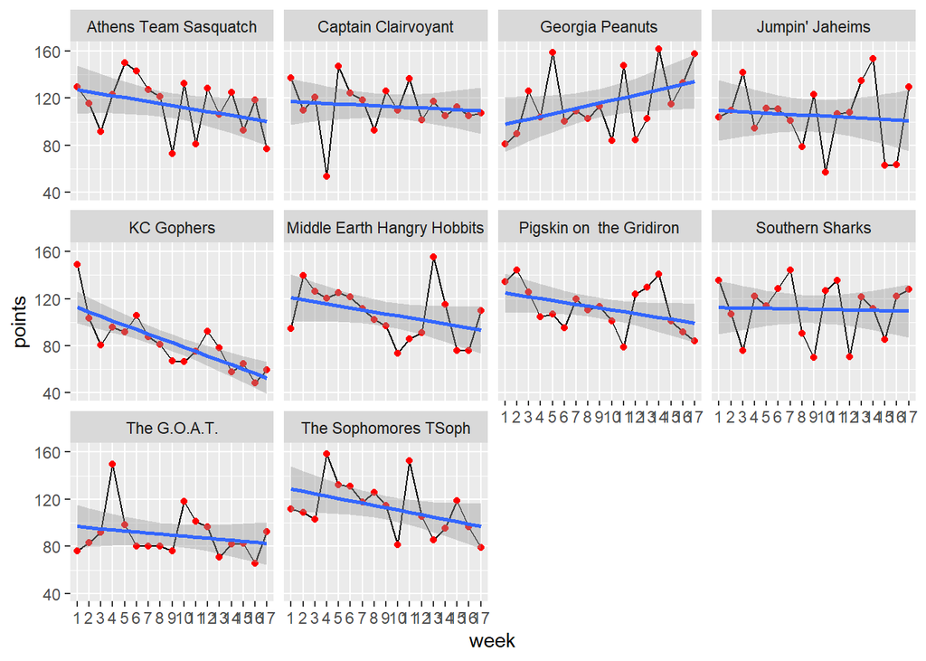

Here’s a NEW graph showing relative standing by week. The y axis is total points relative to the league mean (so negative is below the mean, positive is above).

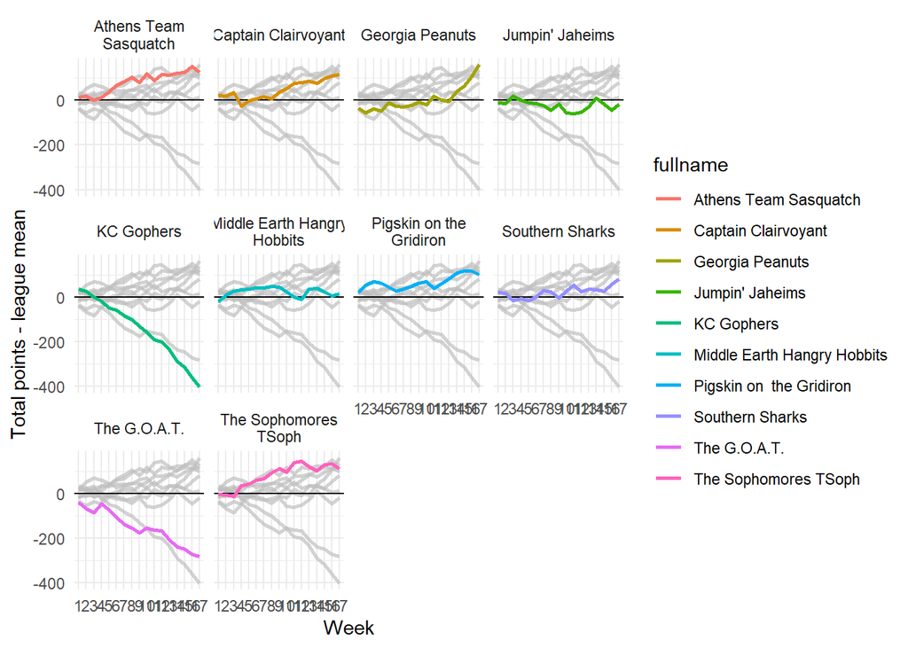

Here’s the graph with all teams together:

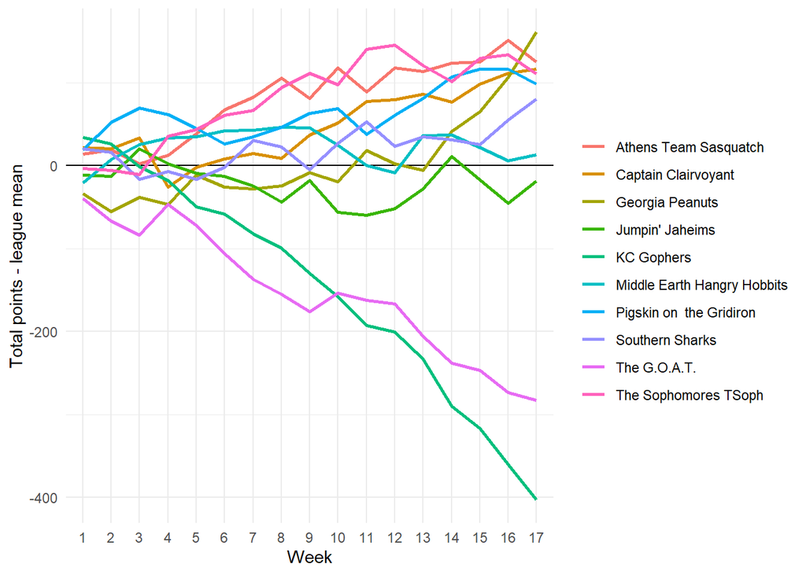

My last few weeks defeinitely stand out here. The GOAT and Gophers had, well, rough ends to the season.

### Quarter season winners

Lastly, let’s take a look at standings by section of the season. We had seventeen weeks, so what if we break those into groups of four?

Quarter 1 (Weeks 1-4):

| fullname | allpoints |
| --- | --- |
| Pigskin on the Gridiron | 508.76 |
| The Sophomores TSoph | 482.38 |
| Middle Earth Hangry Hobbits | 480.44 |
| Athens Team Sasquatch | 459.58 |
| Jumpin’ Jaheims | 449.60 |
| Southern Sharks | 440.18 |
| KC Gophers | 429.32 |
| Captain Clairvoyant | 421.34 |
| Georgia Peanuts | 400.42 |
| The G.O.A.T. | 400.34 |

Quarter 2 (Weeks 5-8):

| fullname | allpoints |
| --- | --- |
| Athens Team Sasquatch | 541.01 |
| The Sophomores TSoph | 506.98 |
| Captain Clairvoyant | 482.56 |
| Southern Sharks | 477.98 |
| Georgia Peanuts | 470.53 |
| Middle Earth Hangry Hobbits | 461.05 |
| Pigskin on the Gridiron | 433.16 |
| Jumpin’ Jaheims | 401.85 |
| KC Gophers | 366.20 |
| The G.O.A.T. | 339.58 |

Quarter 3 (Weeks 9-12):

| fullname | allpoints |
| --- | --- |
| Captain Clairvoyant | 473.42 |
| The Sophomores TSoph | 453.96 |
| Georgia Peanuts | 429.39 |
| Pigskin on the Gridiron | 417.17 |
| Athens Team Sasquatch | 415.01 |
| Southern Sharks | 403.14 |
| Jumpin’ Jaheims | 394.50 |
| The G.O.A.T. | 391.78 |
| Middle Earth Hangry Hobbits | 347.94 |
| KC Gophers | 301.68 |

Quarter 4 (Weeks 13-17)

| fullname | allpoints |
| --- | --- |
| Georgia Peanuts | 669.49 |
| Southern Sharks | 568.00 |
| Pigskin on the Gridiron | 547.78 |
| Captain Clairvoyant | 547.66 |
| Jumpin’ Jaheims | 544.60 |
| Middle Earth Hangry Hobbits | 532.55 |
| Athens Team Sasquatch | 518.43 |
| The Sophomores TSoph | 476.02 |
| The G.O.A.T. | 394.08 |
| KC Gophers | 308.66 |

Gotta play all four quarters, y’all!

This was a fun season. Hoping to catch up with you all at the season ending party and do this again next year.